# New version

Chiara Gilardi

23 maggio 2018

## Logistic Regression for approval

```r
internal_regression_data<-prepare_data_internal_log_regression(final.apps,final.internal)
internal_regression_data$ApplicantTrack <- factor(internal_regression_data$ApplicantTrack, ordered = F)
internal_regression_data$ProjectAssessment <- factor(internal_regression_data$ProjectAssessment, ordered = F)
internal_regression_data$logAmount <- log(internal_regression_data$AmountRequested)
data<- subset(internal_regression_data,select = -c(ProjectID, Ranking, AmountRequested,
                                                   NumberExternalReviewers, NumberInternalReviewers))

## COMBINE GRADES otherwise it doesn't work
data$ApplicantTrack <- ifelse(as.numeric(data$ApplicantTrack) < 4,3,data$ApplicantTrack)
data$ApplicantTrack <- factor(data$ApplicantTrack)
data$ProjectAssessment <- ifelse(as.numeric(data$ProjectAssessment) <4,3,data$ProjectAssessment)
data$ProjectAssessment <- factor(data$ProjectAssessment)
```

```r
Model.log.int <- glm(IsApproved ~. +Gender:Division+ Gender:PercentFemale+ Gender:ApplicantTrack+
                         InstType:Division, data=data, family="binomial")
summary(Model.log.int)
```

```
##
## Call:
## glm(formula = IsApproved ~ . + Gender:Division + Gender:PercentFemale +
##     Gender:ApplicantTrack + InstType:Division, family = "binomial",
##     data = data)
##
## Deviance Residuals:
##     Min       1Q   Median       3Q      Max
## -2.9812  -0.4003   0.1969   0.5198   2.7531
##
## Coefficients:
##                               Estimate Std. Error z value Pr(>|z|)
## (Intercept)                   -0.81605    2.17255  -0.376 0.707200
## Genderf                        0.43769    0.64220   0.682 0.495523
## DivisionDiv 2                  0.11451    0.60949   0.188 0.850971
## DivisionDiv 3                  0.63110    0.73282   0.861 0.389132
## Age                           -0.01350    0.01088  -1.241 0.214539
## SemesterOktober                0.19646    0.16819   1.168 0.242778
## IsContinuation1                0.65210    0.21020   3.102 0.001921 **
## PreviousRequest1              -0.13634    0.24021  -0.568 0.570312
## InstTypeOther                  1.06069    0.82390   1.287 0.197952
## InstTypeUAS/UTE               -0.02592    0.65579  -0.040 0.968478
## InstTypeUni                    0.55379    0.60188   0.920 0.357516
## PercentFemale                 -0.37921    0.24628  -1.540 0.123618
## ApplicantTrack4                0.95719    0.36367   2.632 0.008487 **
## ApplicantTrack5                1.24090    0.37326   3.324 0.000886 ***
## ApplicantTrack6                1.24992    0.49166   2.542 0.011014 *
## ProjectAssessment4             3.32753    0.19185  17.345  < 2e-16 ***
## ProjectAssessment5             5.62313    0.33760  16.656  < 2e-16 ***
## ProjectAssessment6             5.77784    0.77671   7.439 1.02e-13 ***
## logAmount                     -0.17629    0.16232  -1.086 0.277442
## Genderf:DivisionDiv 2         -0.17511    0.51628  -0.339 0.734481
## Genderf:DivisionDiv 3          0.32107    0.45765   0.702 0.482951
## Genderf:PercentFemale         -0.37254    0.45785  -0.814 0.415833
## Genderf:ApplicantTrack4       -0.56695    0.63393  -0.894 0.371140
## Genderf:ApplicantTrack5        0.03093    0.67656   0.046 0.963536
## Genderf:ApplicantTrack6       -0.58313    0.96566  -0.604 0.545934
## DivisionDiv 2:InstTypeOther   -1.44435    1.01910  -1.417 0.156400
## DivisionDiv 3:InstTypeOther   -1.71915    1.06561  -1.613 0.106680
## DivisionDiv 2:InstTypeUAS/UTE -0.37051    1.12149  -0.330 0.741117
## DivisionDiv 3:InstTypeUAS/UTE -0.15194    1.17655  -0.129 0.897245
## DivisionDiv 2:InstTypeUni     -0.47593    0.66853  -0.712 0.476523
## DivisionDiv 3:InstTypeUni     -1.01993    0.75996  -1.342 0.179565
## ---
## Signif. codes:  0 '***' 0.001 '**' 0.01 '*' 0.05 '.' 0.1 ' ' 1
##
## (Dispersion parameter for binomial family taken to be 1)
##
##     Null deviance: 2243.9  on 1622  degrees of freedom
## Residual deviance: 1059.9  on 1592  degrees of freedom
## AIC: 1121.9
##
## Number of Fisher Scoring iterations: 6
```

```r
coef.log <- Model.log.int$coefficients
CI <- confint(Model.log.int)
PsR2.small<-(1-exp((Model.log.int$dev-Model.log.int$null)/1623))/(1-exp(-Model.log.int$null/1623)) #0.69135
```

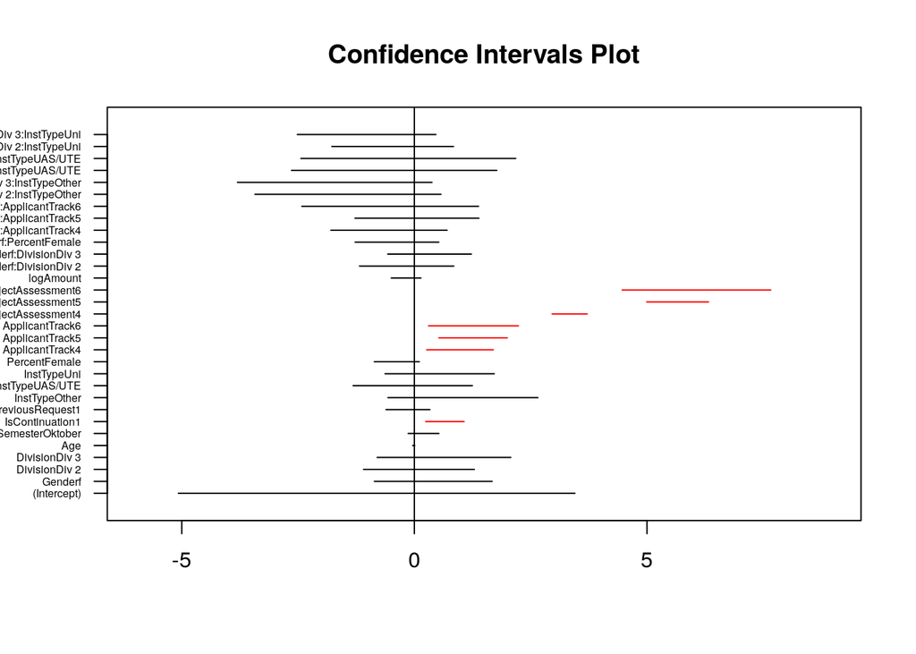

```r
plot(0,xlim=c(-6,9), yaxt="n", pch="", ylim=c(0,32), main="Confidence Intervals Plot", ylab="",xlab="")
abline(v=0)
axis(2,1:31, rownames(CI), las = 1, cex.axis=0.5)
for (i in 1:length(coef.log)) {
  interval <- c(CI[i,1], CI[i,2])
  col <- "black"
  if (interval[1] > 0 & 0 < interval[2]) {col="red"}
  lines(interval, c(i,i),col=col)
}
```

```r
sign.coef <- coef.log[which(CI[,1]>0 & CI[,2]>0)]
sign.OR <- exp(sign.coef)
sign.OR
```

```
##    IsContinuation1    ApplicantTrack4    ApplicantTrack5
##           1.919569           2.604369           3.458732
##    ApplicantTrack6 ProjectAssessment4 ProjectAssessment5
##           3.490055          27.869369         276.755311
## ProjectAssessment6
##         323.059764
```

The interpretation of the coefficients is the following: * If the project is a continuation, it is 1.91 times more likely to be approved than if it’s not * If the Applicant Track grade is 4, the proposal is 2.6 times more likely to be approved than a 3 or lower * If the Applicant Track grade is 5, the proposal is 3.5 times more likely to be approved than a 3 or lower * If the Applicant Track grade is 6, the proposal is 3.5 times more likely to be approved than a 3 or lower * If the Project Assessment grade is 4, the proposal is 27.9 times more likely to be approved than a 3 or lower * If the Project Assessment grade is 5, the proposal is 276 times more likely to be approved than a 3 or lower * If the Project Assessment grade is 6, the proposal is 323 times more likely to be approved than a 3 or lower

Notice that the coefficient for gender is not significant, since its confidence interval (-0.8597,1.6701) contains zero. The point estimate for gender is 0.4376931 and this means that a woman is 1.5491294 times more likely to be approved than a man.

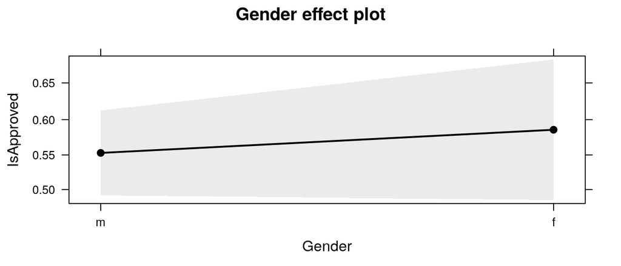

```r
# Obtain all the effects
  eff.fit <- allEffects(Model.log.int)

# Obtain Gender effect as a separate data frame
  eff<-Effect("Gender", Model.log.int)
  eff<-eff$fit
  prob<- round((exp(eff)/(1+exp(eff))),3)

  plot(Effect("Gender",Model.log.int),
       confint=list(style="band",alpha=0.3,col="grey"),
       lines=list(col=1))
```

## Ordinal regression for Project Assessment

```r
internal_regression_data<-prepare_data_internal_log_regression(final.apps,final.internal)
# internal_regression_data$Semester <- revalue(internal_regression_data$Semester, c("ottobre"="Oct", "aprile"="Apr"))
internal_regression_data$Semester <- revalue(internal_regression_data$Semester, c("Oktober"="Oct", "April"="Apr"))
internal_regression_data$logAmount <- log(internal_regression_data$AmountRequested)

# Final Model after variable selection
Model.project <- clm(ProjectAssessment ~ Gender + Division + PercentFemale + Age +
               IsContinuation + InstType + logAmount, data=internal_regression_data)

Model2.project <- clm(ProjectAssessment ~ Division + PercentFemale + Age +
                IsContinuation + InstType + logAmount, data=internal_regression_data)

# Compare the models using Bonferroni correction
pvalue <- anova(Model2.project, Model.project)[2,6]
```

```r
X<-Model.project$model[,-1]
newdata<-data.frame(Gender="f", Division="Div 1", PercentFemale=0,
        Age=48, IsContinuation="0",logAmount=13.02518, InstType="Uni")
fitted <- predict(Model.project,newdata=newdata, type = "cum.prob")
f.cum.prob<-fitted$cprob2
fitted <- predict(Model.project,newdata=newdata)
f.prob<-fitted$fit

newdata<-data.frame(Gender="m",Division="Div 1", PercentFemale=0,
        Age=48,IsContinuation="0",logAmount=13.02518,InstType="Uni")
fitted <- predict(Model.project,newdata=newdata, type = "cum.prob")
m.cum.prob<-fitted$cprob2
fitted <- predict(Model.project,newdata=newdata)
m.prob<-fitted$fit

gender.prob.project<-rbind(m.prob, f.prob)
rownames(gender.prob.project)<-c("Male","Female")
colnames(gender.prob.project)<-c("poor","average","good", "very good",
                               "excellent","outstanding")

gender.prob.project<-t(gender.prob.project)
gender.prob.project<-cbind(round(gender.prob.project,3),
Difference=round((gender.prob.project[,1]-gender.prob.project[,2]),3))
gender.prob.project<-as.data.frame(gender.prob.project)
gender.prob.project
```

```
##              Male Female Difference
## poor        0.021  0.026     -0.006
## average     0.146  0.177     -0.031
## good        0.320  0.345     -0.024
## very good   0.319  0.293      0.026
## excellent   0.171  0.140      0.031
## outstanding 0.023  0.018      0.005
```

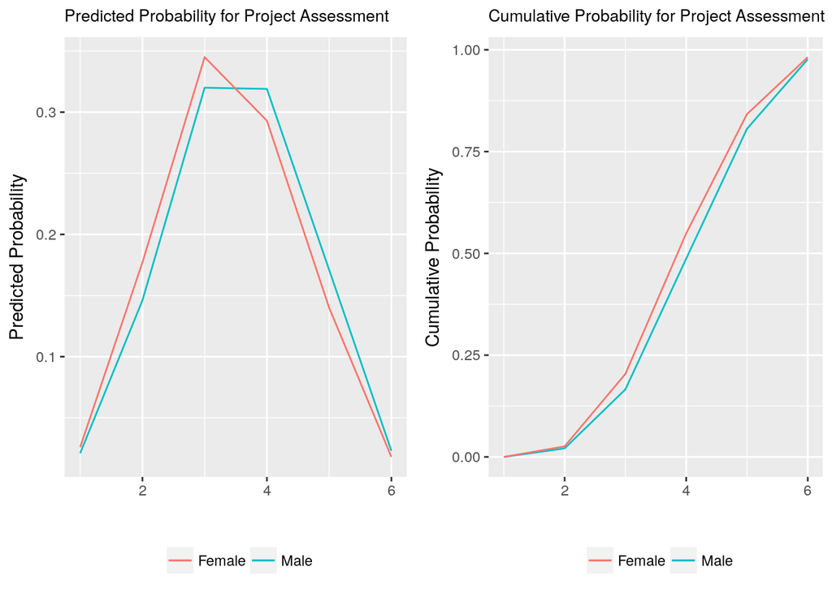

```r
p1 <- ggplot(gender.prob.project) +
  geom_line(aes(1:6, Male, colour = "Male")) +
  geom_line(aes(1:6, Female, colour = "Female"))+
  theme(legend.title=element_blank(),legend.position = "bottom")+
  xlab("")+ylab("Predicted Probability")+
  ggtitle("Predicted Probability for Project Assessment")+
  theme(plot.title = element_text(size=10))

# Cumulative probability
gender.cum.prob.project<-rbind(m.cum.prob, f.cum.prob)
rownames(gender.cum.prob.project)<-c("Male","Female")
colnames(gender.cum.prob.project)<-c("poor","average","good", "very good",
                                   "excellent","outstanding")

gender.cum.prob.project<-t(gender.cum.prob.project)
gender.cum.prob.project<-cbind(round(gender.cum.prob.project,3),
 Difference=round((gender.cum.prob.project[,1]-gender.cum.prob.project[,2]),3))
gender.cum.prob.project<-as.data.frame(gender.cum.prob.project)

p2 <- ggplot(gender.cum.prob.project) +
  geom_line(aes(1:6, Male, colour = "Male")) +
  geom_line(aes(1:6, Female, colour = "Female"))+
  theme(legend.title=element_blank(),legend.position = "bottom")+
  xlab("")+ylab("Cumulative Probability")+
  ggtitle("Cumulative Probability for Project Assessment")+
  theme(plot.title = element_text(size=10))

grid.arrange(p1, p2, ncol=2)
```

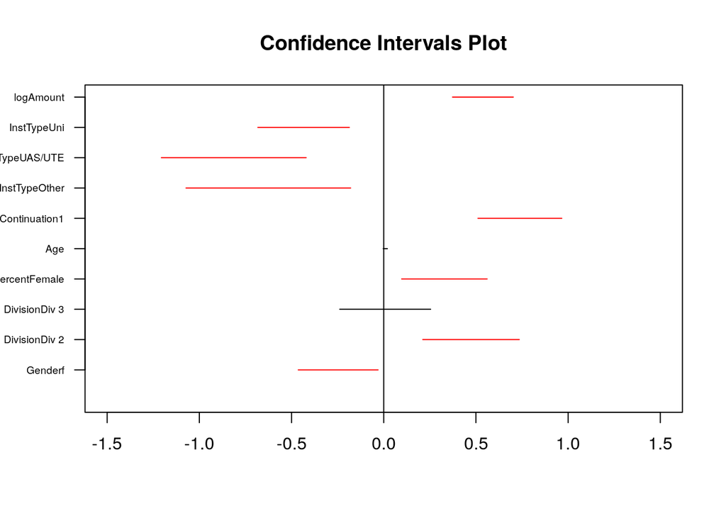

```r
CI.project <- confint(Model.project)
plot(0,0,xlim=c(-1.5,1.5), pch="",yaxt="n", ylim=c(0,nrow(CI.project)), main="Confidence Intervals Plot", ylab="",xlab="")
abline(v=0)
axis(2,1:nrow(CI.project), rownames(CI.project), las = 1, cex.axis=0.6)
for (i in 1:nrow(CI.project)) {
  interval <- c(CI.project[i,1], CI.project[i,2])
  col <- "black"
  if (interval[1] > 0 & 0 < interval[2]) {col="red"}
  if (interval[1] < 0 & 0 > interval[2]) {col="red"}
  lines(interval, c(i,i),col=col)
}
```

From the plot above we can see that gender seems to be significant, even if the confidence interval upper bound is really close zero. The other significant predictors are Division, the percentage of female reviewers, if the project is a continuation, the Institution type and the log(AmountRequested).